# Process Seurat Object

```r
library(scpackages)
```

## Process Seurat Object for clustering

First we will load saved seurat object from disk.

```r
seuratObj <- readRDS("/home/dasroy/data/Project/scpackages/1k_Brain_E18_Mm.12_February_2020.rds")
```

## 3-in-1

There are three steps need to do at first ; which are

- Normalization
- VariableFeatures (find variable genes)
- ScaleData

These steps can be done by a single method with default values. It will also genarate **VariableFeaturePlot**. Only the variable features will be scaled as those are only required as input for PCA.

**Note** We can pass any parameter of above “Seurat” functions to below function. Here in this example **nfeatures** belongs to **VariableFeatures** .

```r
seuratObj <- normScaleHVG(seuratObj,seuratVerbose = FALSE,nfeatures=1000)
```

```
## When using repel, set xnudge and ynudge to 0 for optimal results
```

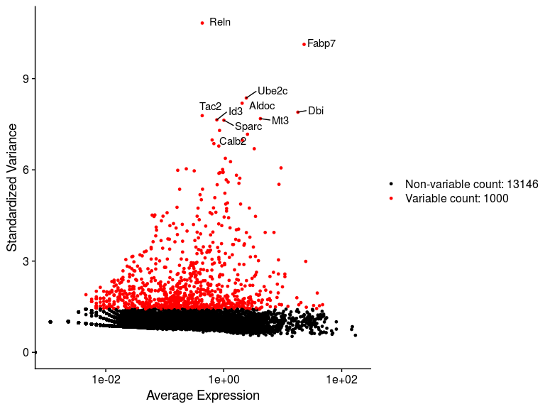

To save the variance info of all the genes in a csv file.

```r
tmp_hvf <-HVFInfo(seuratObj)
tmp_hvf$Symbol <- rownames(tmp_hvf)
write.csv(tmp_hvf, file = "HVF_info.csv",row.names = FALSE)
```

## CellCycle

Next we will check

```r
library(readr)
cell_cycle_genes <- read_csv(system.file("extdata", "cell_cycle_genes.csv", package = "scpackages"))
cell_cycle_genes
```

```
## # A tibble: 542 x 5
##    Symbol  SubPhase source  Phase alternative
##    <chr>   <chr>    <chr>   <chr> <chr>
##  1 Acd     G1/S     Macosko S     <NA>
##  2 Acyp1   G1/S     Macosko S     <NA>
##  3 Adamts1 G1/S     Macosko S     <NA>
##  4 Ankrd10 G1/S     Macosko S     <NA>
##  5 Apex2   G1/S     Macosko S     <NA>
##  6 Arglu1  G1/S     Macosko S     <NA>
##  7 Atad2   G1/S     Macosko S     <NA>
##  8 Bard1   G1/S     Macosko S     <NA>
##  9 Brd7    G1/S     Macosko S     <NA>
## 10 Rsrp1   G1/S     Macosko S     C1orf63
## # … with 532 more rows
```

**NOTE** cell_cycle_genes should have columns “Symbol” for gene names and “Phase” with values (S and M) for cell-cycle phases

### Regression

At this step we will check

- Principal components(PC) are loaded with cell-cycle (CC) genes.
- PCA plot with CC genes
- regressing out CC effect with Seurat method **CellCycleScoring**
- Again PCA plot with CC genes

```r
seuratObj <-qc_regress_CellCycle(seuratObj, cell_cycle_genes)
```

```
## [1] "Checking Cell cycle gene loadings on PCs"
```

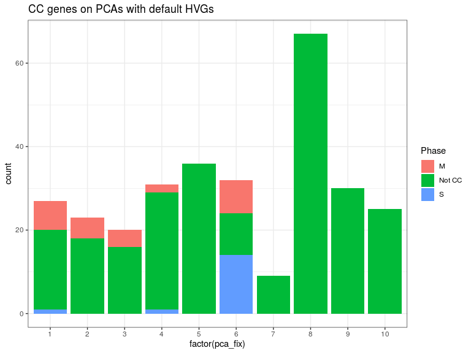

```
## [1] "Running PCA with only cell-cycle genes"
```

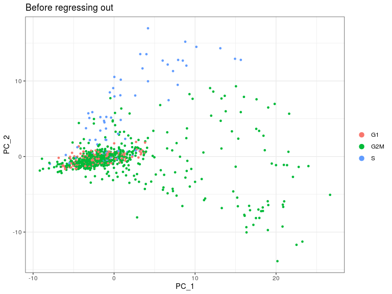

```
## [1] "Regressing out"
## [1] "Checking Cell cycle gene loadings on PCs after regressing out"
```

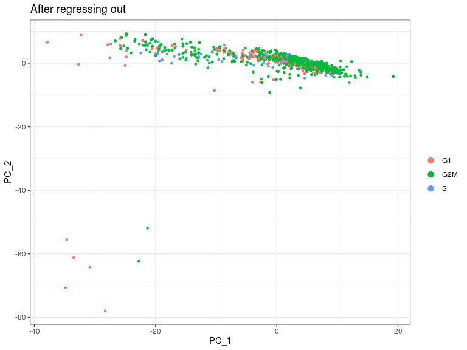

Plots will be saved in this following slots.

- ‘seuratObj@misc$CC_pca_bar’
- ‘seuratObj@misc$before_cc_pca’
- ‘seuratObj@misc$after_cc_pca’

## Cluster

### Elbowplot

```r
seuratObj <- pcaProcess(seuratObj,features = VariableFeatures(seuratObj),jackStraw = FALSE)
```

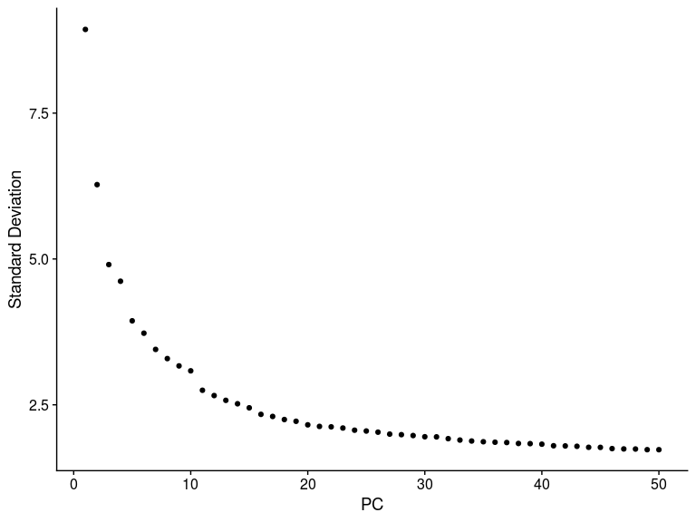

```r
# seuratObj@misc$elbowPlot
```

### Clustering

```r
seuratObj <- makeClusterSeurat(seuratObj,maxDims = 20, res = 0.5)
```

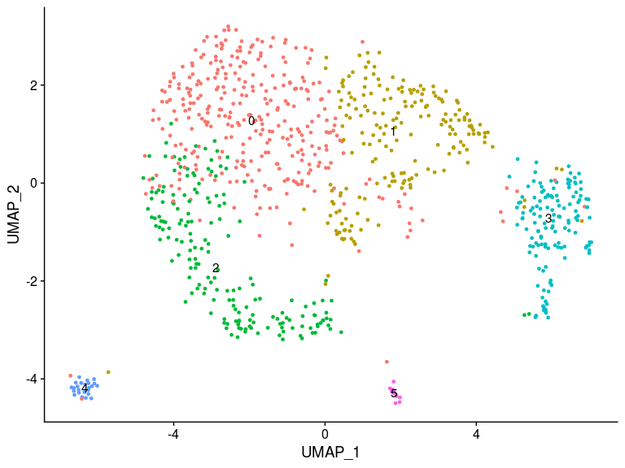

```r
# seuratObj@misc$umapPlot
```

### Cluster markers

```r
markers_info <-  FindAllMarkers( object = seuratObj,
                                 only.pos = TRUE, min.pct = 0.25,
                                 thresh.use = 0.25, verbose = FALSE )
head(markers_info)
```

```
##                p_val avg_logFC pct.1 pct.2    p_val_adj cluster    gene
## Cd24a   1.740056e-52 0.6196500 0.988 0.941 2.461483e-48       0   Cd24a
## Gpm6a   1.226113e-50 0.7530039 0.963 0.701 1.734459e-46       0   Gpm6a
## Tsc22d1 2.907158e-50 0.6479096 0.985 0.939 4.112466e-46       0 Tsc22d1
## Neurod2 3.197984e-50 0.6841526 0.973 0.711 4.523868e-46       0 Neurod2
## Gria2   4.798070e-49 0.7361494 0.976 0.724 6.787350e-45       0   Gria2
## Myt1l   1.680443e-45 0.6963731 0.860 0.453 2.377155e-41       0   Myt1l
```

```r
seuratObj@misc$markers_info <- markers_info
```

To save the **markers_info** in a csv file.

```r
write.csv(markers_info, file = "cluster_markers.csv",row.names = FALSE)
```

#### Cell type information

Dummy cell type info. This data source must have two columns “Symbol” and “Gene_type”

```r
marker_gene <- read_csv("/home/dasroy/data/Project/GeneExpression/scrna_workflow/marker_genes.csv")
marker_gene <- marker_gene[!duplicated(marker_gene$Symbol),]
head(marker_gene)
```

```
## # A tibble: 6 x 3
##   Symbol Gene_type source
##   <chr>  <chr>     <chr>
## 1 H2-M2  Placode   Sennett
## 2 Shh    Placode   Sennett
## 3 Ascl4  Placode   Sennett
## 4 Dkk4   Placode   Sennett
## 5 Fgf20  Placode   Sennett
## 6 Pthlh  Placode   Sennett
```

#### Annotation

```r
library(dplyr)
markers_info <- left_join(markers_info,marker_gene,
                          by = c("gene" = "Symbol")) %>%
    replace_na(list(Gene_type = "Non skin"))

# Storing the info
seuratObj@misc$markers_info <- markers_info
```

#### Rename clusters

```r
seuratObj <- renameCluster(ClusterInfo = markers_info, Object = seuratObj)
```

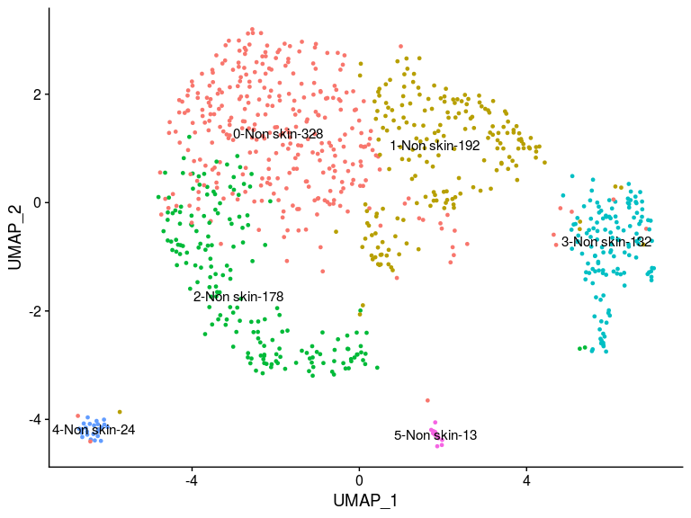

We used genes which should express in developing skin and hence all the clusters are marked with non-skin genes. The third field of the cluster names reflect the cluster sizes.

## Report

It will genarate report and save seuratObj with filenames begining with **title** and ending with date_stamp.

```r
report_Cluster(obj_scRNA = seuratObj,title = "../scaled_cluster")
```

```
## [1] "Saving data ../scaled_cluster.14_February_2020.rds"
```